# Women in Chicago Ultimate Data Analysis

Ladies of Chicago Ultimate

Winter 2017

# Outline

- Munge
  - When possible, data was pulled straight from the raw data files and assigned codes in R. When not possible, data was pulled from hand-coded data source
  - Predictor variable from raw: `age`, `where_live`, `team`, `currently_playing`, `how_long_play`, `start_playing`, `first_experience`
  - Predictor variables derived: `team_type` (derived from team), `club_or_not` (derived from team type)
  - Response variables: `satis_amount_recode`, `satis_level_recode`, `conn_club`, `conn_recreational`, `conn_college`, `conn_youth`, `inclus_UC`, `inclus_college`, `inclus_women`, `inclus_mixed`
  - Response variables derived: `satis_combined` (sum of satisfaction), `conn_combined` (sum of connectedness), `inclus_combined` (sum of inclusiveness), `overall` (sum of sums)
- Plot
  - Focused on showing the effect of `team_type` outcome variables as it was the best predictor of all the independent variables
  - A limitation of our data is that we only collected non-continuous data in both predictor and response variables. For that reason, all of the point plots are “jittered” (random noise introduced) so that they’re a bit more visually interpretable.
- Model
  - Ordered Logistic/Probit Regressions for ordered categorical response variables
  - OLS regression for summed categorical response variables
  - Only looking at main effects for now, no interations
- Main takeaway
  - `team_type` was a significant predictor of general happiness with ultimate in Chicago. Nothing else was really significant.
  - Directionality: Non-club players feel less satisfied, connected, and included than club players
  - There isn’t a significant difference between how happy/satisfied women’s players and mixed players feel

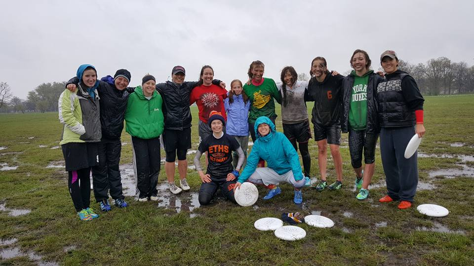

## Munge

```r
source("./munge.R")
source("./summary_stats.R")
```

```
## # A tibble: 2 x 2
##   club_or_not     n
##        <fctr> <int>
## 1        club    70
## 2    not_club    94
## # A tibble: 3 x 2
##        where_live     n
##            <fctr> <int>
## 1         Chicago   114
## 2 Chicago Suburbs    41
## 3           Other     9
## # A tibble: 5 x 2
##   how_long_play     n
##          <fctr> <int>
## 1       <1 year     9
## 2     1-3 years    25
## 3     3-5 years    36
## 4    5-10 years    56
## 5     10+ years    38
## # A tibble: 11 x 2
##              team     n
##            <fctr> <int>
##  1           Dish    16
##  2        ELevate    10
##  3         Frenzy    15
##  4        No-Club    78
##  5    Non-Chicago    10
##  6 Jabba The Huck     4
##  7        Nemesis     9
##  8          Other     6
##  9      Shakedown     6
## 10     Stack Cats     7
## 11            UPA     3
## # A tibble: 6 x 2
##                      currently_playing     n
##                                 <fctr> <int>
## 1                          League Only    42
## 2 Combination of League, Club, College    34
## 3                            Club Only    23
## 4                         College Only    18
```

[output cut: 9 more lines]

```
## # A tibble: 3 x 2
##   start_playing     n
##          <fctr> <int>
## 1   High School    35
## 2       College    93
## 3  Post-College    34
## # A tibble: 6 x 2
##        age     n
##     <fctr> <int>
## 1 Under 18     3
## 2    18-22    38
## 3    23-26    44
## 4    27-30    35
## 5    31-36    28
## 6      37+    16
```

- Variables collected on a Lickert scale were treated ordinally. Otherwise, treated categorically.
- Categorize teams into
  - a variable `team_type` with three levels: `mixed`, `no_club`, and `womens`. All players not on a womens or mixed team are `no_club` (which is a little misleading because this encompasses non-Chicago club teams)
  - a variable `club_or_not` with two levels: `club` and `not_club`
- When the outcome variable is an ordered factor (e.g., “How satisfied are you with the AMOUNT of ultimate you are currently playing?”)
  - Run an ordered probit regression with some number of predictor variables predicting that single outcome variable
- Combine ordered categorical predictor variables into omnibus variables and treat them as continuous
  - The idea with summing ordinal response variables was to introduce more degrees of freedom into the outcome variable so that we could run a more standard linear regression rather than an ordered/logistic probit regression on each outcome variable. It hopefully gives us both more predictive power and a more holistic look at three main categories of response variable (satisfaction, connectedness, and inclusiveness)
  - These are: `satis_combined`, `conn_combined`, `inclus_combined`, and their sum, `overall`

Caveat: while directionality is constant across different variables (i.e., 1 always = bad or disagree or whatever), there are different levels for different variables that aren’t necessarily comparable. They’re ordered in a way that makes the most sense, I think, but you could definitely argue for a different ordering.

For example, for the question “How satisfied are you with the AMOUNT of ultimate you are currently playing?”, is this the right ordering?

Not satisfied: wants more < Not satisfied: wants less < Neutral < Other < Somewhat satisfied: wants more < Somewhat satisfied: wants less < Very satisfied

`¯\_(ツ)_/¯`

Something to try here might be to take out all the Others and relevel. Or combine things like “Not satisfied: wants more” and “Not satisfied: wants less” into the same level.

## Summary Stats

Snapshot of the top of the data:

| Particiapnt: | Age: | Please choose the option that best describes where you currently live. | May we anonymously quote your answers from this survey? | Do you currently play or practice with a Chicago-based club team? | Please indicate the ultimate you are playing (or registered for) right now: | How long have you been playing ultimate? | At what point in your life did you start playing ultimate? | What best describes your first ultimate experience? | How satisfied are you with the AMOUNT of ultimate you are currently playing? | How satisfied are you with the LEVEL of ultimate you are currently playing? | How connected do you feel to the CLUB ultimate community in Chicago? | How connected do you feel to the RECREATIONAL ultimate community in Chicago? (e.g. UC leagues, pickup) | How connected do you feel to the COLLEGE ultimate community in Chicago? | How connected do you feel to the YOUTH ultimate community in Chicago? (e.g. CUJO, YCC, high school, middle school, etc.) | Ultimate Chicago supports the development and inclusion of women in ultimate. | College ultimate teams support the development and inclusion of women in ultimate. | Women’s club teams support the development and inclusion of women in ultimate. | Mixed club teams support the development and inclusion of women in ultimate. |
| --- | --- | --- | --- | --- | --- | --- | --- | --- | --- | --- | --- | --- | --- | --- | --- | --- | --- | --- |
| A | 18-22 | I live in Chicago. | Yes, you may anonymously quote my answers to further this project. | Frenzy | Women’s Club, College women’s | <1 year | College | College women’s team | Somewhat satisfied – I sometimes wish I could play more, but overall I’m happy with the amount that I play. | Somewhat satisfied – I sometimes wish I could play more competitively, but overall I’m satisfied with the level that I play. | Somewhat connected | Neutral | Somewhat connected | Disconnected | Neutral - I don’t have an opinion here. | Agree | Agree | Somewhat disagree |
| B | 37+ | I live in a Chicago suburb. | Yes, you may anonymously quote my answers to further this project. | UPA | Mixed Club | 10+ years | Post-college | Recreational league (e.g. an Ultimate Chicago league) | Very satisfied – I’m playing just the right amount | Very satisfied – I have the opportunity to play at the right level of competitiveness for me. | Somewhat connected | Somewhat disconnected | Disconnected | Somewhat connected | Agree | Neutral - I don’t have an opinion here. | Agree | Neutral - I don’t have an opinion |
| C | 31-36 | I live in Chicago. | Yes, you may anonymously quote my answers to further this project. | I don’t play on a Chicago-based club team. | UC Fall League (Mixed) | 5-10 years | Post-college | Recreational league (e.g. an Ultimate Chicago league) | Neutral – I don’t have strong feelings about the amount of ultimate I’m playing. | Somewhat satisfied – I sometimes wish I could play more competitively, but overall I’m satisfied with the level that I play. | Disconnected | Somewhat connected | Disconnected | Disconnected | Somewhat Agree | Neutral - I don’t have an opinion here. | Neutral - I don’t have an opinion here. | Neutral - I don’t have an opinion |

*What were the variables considered?*

**Predictor variables**

[output not shown]

**Outcome variables**

| Variable | Name |
| --- | --- |
| satis_amount_recode | How satisfied are you with the AMOUNT of ultimate you are currently playing? |
| satis_level_recode | How satisfied are you with the LEVEL of ultimate you are currently playing? |
| conn_club | How connected do you feel to the CLUB ultimate community in Chicago? |
| conn_recreational | How connected do you feel to the RECREATIONAL ultimate community in Chicago? (e.g. UC leagues, pickup) |
| conn_college | How connected do you feel to the COLLEGE ultimate community in Chicago? |
| conn_youth | How connected do you feel to the YOUTH ultimate community in Chicago? (e.g. CUJO, YCC, high school, middle school, etc.) |
| inclus_UC | Ultimate Chicago supports the development and inclusion of women in ultimate. |
| inclus_college | College ultimate teams support the development and inclusion of women in ultimate. |
| inclus_women | Women’s club teams support the development and inclusion of women in ultimate. |
| inclus_mixed | Mixed club teams support the development and inclusion of women in ultimate. |

*Outcome variable summary*

- Means by team of the omnibus variables `satis_combined`, `conn_combined`, `inclus_combined`, ordered by their sum, `overall`
- For a sneak peek of the main finding, check that team type column

| Team Type | Team | Satisfaction | Connectedness | Inclusion | Overall |
| --- | --- | --- | --- | --- | --- |
| No Club | No-Club | 9.92 | 9.03 | 15.32 | 34.27 |
| No Club | Other | 11.00 | 10.00 | 13.83 | 34.83 |
| No Club | Non-Chicago | 11.10 | 10.40 | 16.20 | 37.70 |
| Mixed | ELevate | 11.00 | 10.60 | 17.30 | 38.90 |
| Mixed | UPA | 13.33 | 10.67 | 15.00 | 39.00 |
| Womens | Dish | 10.75 | 12.31 | 16.12 | 39.19 |
| Mixed | Shakedown | 11.67 | 10.00 | 18.17 | 39.83 |
| Mixed | Stack Cats | 10.86 | 11.71 | 17.43 | 40.00 |
| Womens | Frenzy | 11.40 | 12.00 | 17.20 | 40.60 |
| Womens | Nemesis | 11.78 | 12.22 | 16.89 | 40.89 |
| Mixed | Jabba The Huck | 11.75 | 13.50 | 17.75 | 43.00 |

## Some Charts

Have some histograms of some predictor variables:

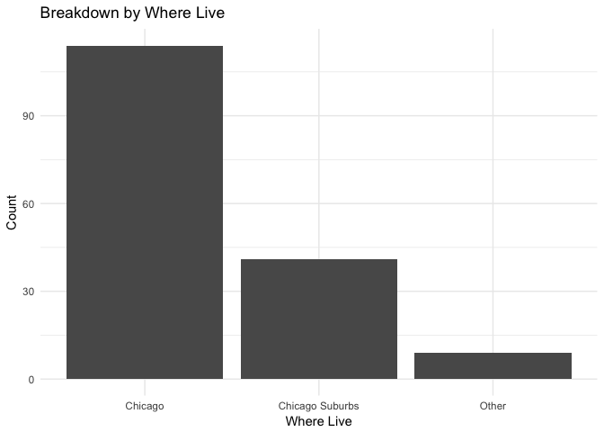

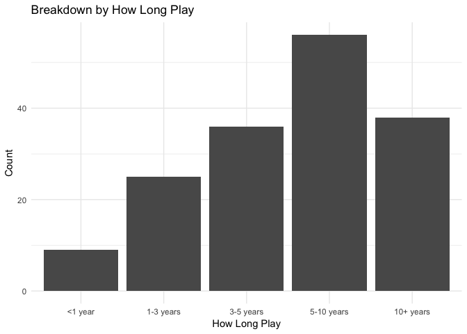

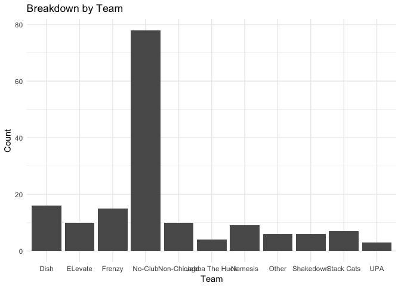

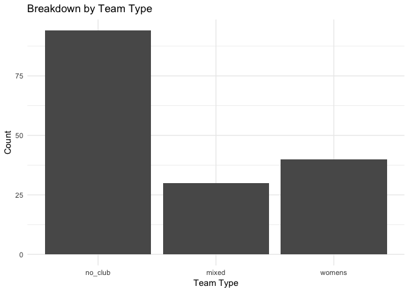

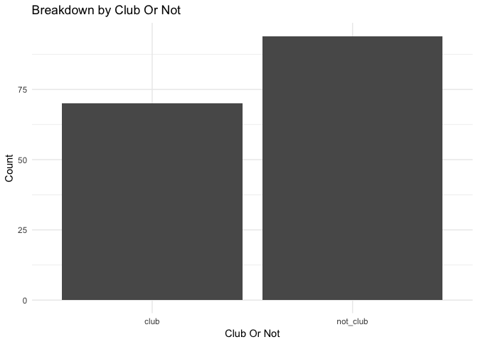

[figure not shown]

## A smattering of other charts

- These are just examples of the types of graphs we could make, depending on what people are interested in looking at – they’re not necessarily particularly meaningful in and of themselves

**What people are playing by their team**

- Note that many people took the survey after their seasons had ended so what they play in season might != what they said they were `currently_playing`

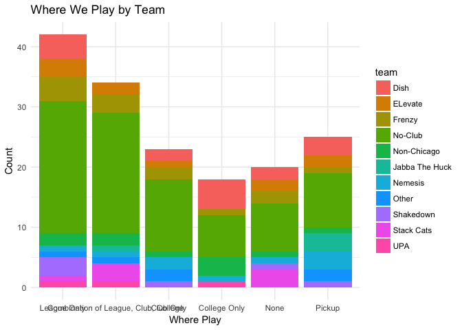

**Jittered `age` (ordinal) vs. overall happiness w/ boxplot of `overall` superimposed**

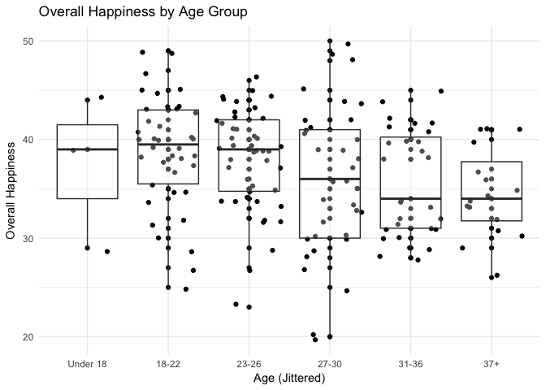

### Drilling down into team_type

**Non-Club: How long have non-Chicago club players been playing?**

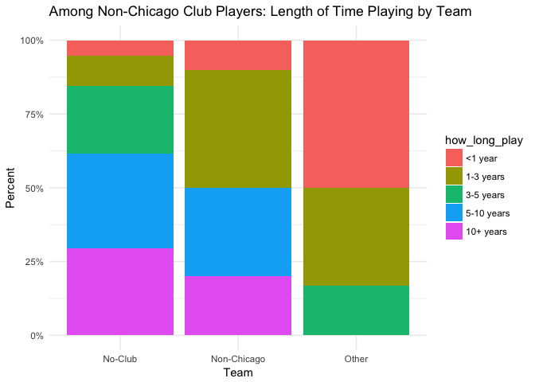

**Womens: age predicting overall happiness**

(Best fit lines are fitted using the linear `method = "lm"`)

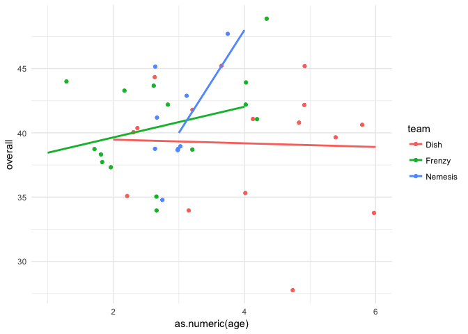

**Mixed: where you started playing predicting overall satisfaction**

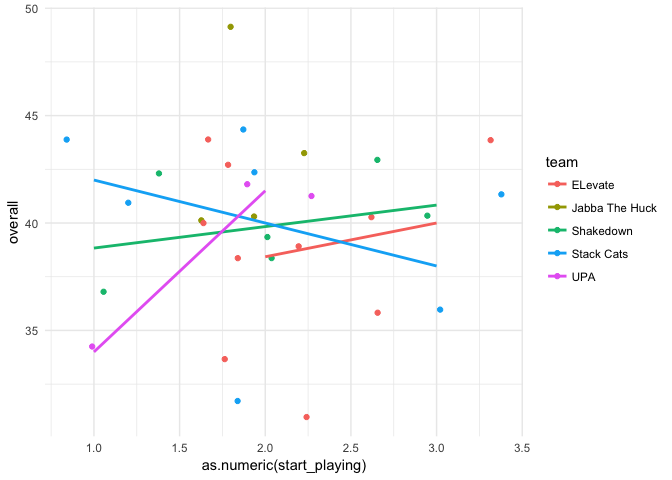

## Cluster Analyses

Can we suss out some clusters with k-means (less greedy) or heirarhical clustering (more greedy)?

### K-Means clustering

- Dependent variable here is `overall` happiness.

Hypothesis:

- Unsupervised clustering into two groups –> fault line will be the `club` vs. `no_club` divide.
- Into three groups –> clusters will mainly represent the three `team_type`s

Setup:

- Pare down the data to only the outcome variable, `overall`, and the predictor variables `age`, `where_live`, `currently_playing`, `how_long_play`, `start_playing`, and `first_experience`. So we take out `team`, `team_type`, and `club_or_not` because these are implicated in the hypothesis
- Set a kmeans algorithm on the new data
- Tell the algorithm we want it to cluster the data into two clusters based on the outcome variable
- Glue this output (a series of 1 and 2s depending on which cluster each row was assigned to) along with the team varibles we took out all back together
- Data is jittered for interpretability

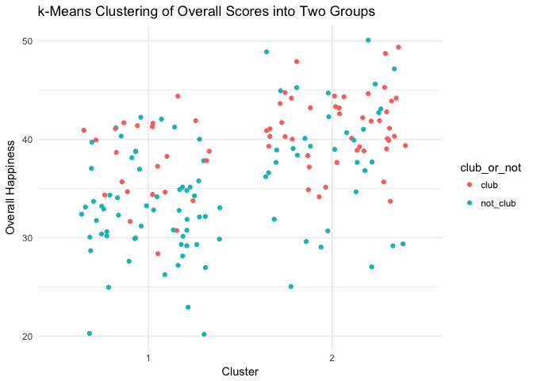

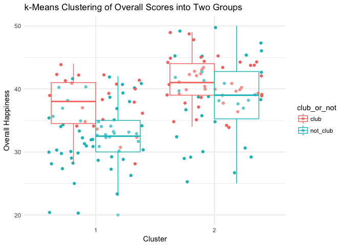

Colored by team type rather than club or not.

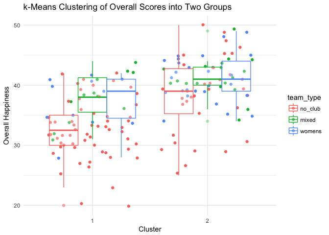

Three clusters doesn’t give us much more information.

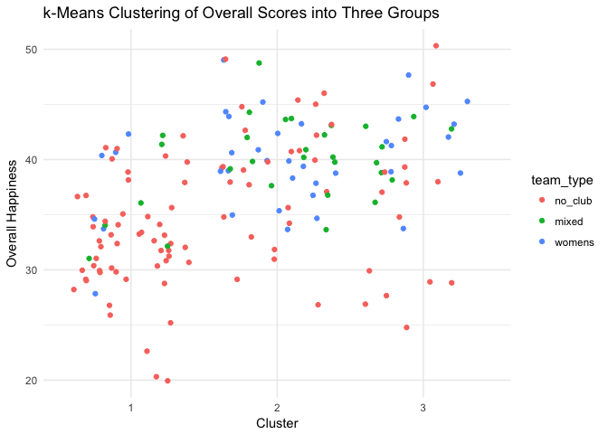

### Hierarchical Clustering

- Dependent vars: inclusion and connectedness
- Grouping var: `age`

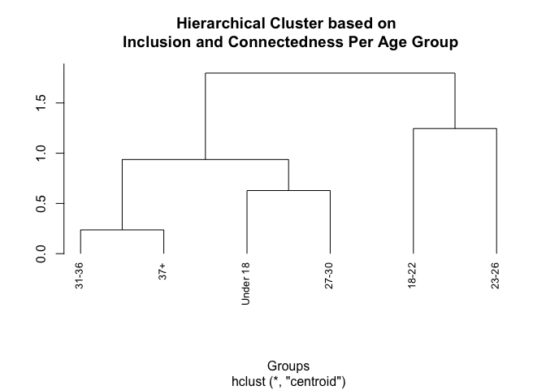

These age clusters seem to make pretty good sense. Try a similar clustering strategy based on team.

- Dependent vars: satisfaction amount and satisfaction level
- Grouping var: `team`

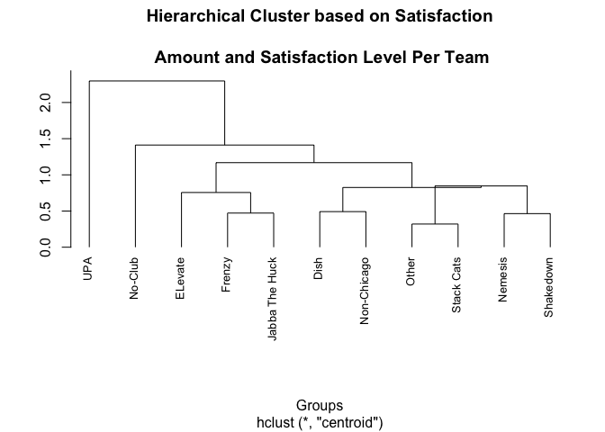

## Models

Omnibus model with all predictors predicting the overall measure. (Not including `team` here because it is binned by `team_type`)

- Throw all the predictors in and see what comes out significant

```
##
## Call:
## lm(formula = overall ~ age + team_type + currently_playing +
##     how_long_play + start_playing + where_live, data = all)
##
## Residuals:
##      Min       1Q   Median       3Q      Max
## -13.0696  -3.4739   0.0624   3.7653  14.0166
##
## Coefficients:
##                                                       Estimate Std. Error
## (Intercept)                                           32.90297    3.99805
## age18-22                                               2.68149    3.36408
## age23-26                                              -0.08609    3.47142
## age27-30                                              -0.71080    3.52003
## age31-36                                              -0.41322    3.62095
## age37+                                                -0.94724    3.88305
## team_typemixed                                         5.37783    1.19311
## team_typewomens                                        5.25785    1.08403
## currently_playingCombination of League, Club, College -0.47972    1.29751
## currently_playingClub Only                             1.60337    1.47372
## currently_playingCollege Only                         -0.52073    1.58414
## currently_playingNone                                  1.67638    1.53268
## currently_playingPickup                                0.75467    1.39828
## how_long_play1-3 years                                 3.08841    2.20120
## how_long_play3-5 years                                -0.05335    2.11730
## how_long_play5-10 years                                2.97843    2.20525
## how_long_play10+ years                                 1.84283    2.49987
## start_playingCollege                                  -0.48566    1.13929
## start_playingPost-College                             -0.86360    1.40399
## where_liveChicago Suburbs                             -0.84417    1.02970
## where_liveOther                                       -2.79567    2.08464
##                                                       t value Pr(>|t|)
## (Intercept)                                             8.230 1.13e-13 ***
## age18-22                                                0.797    0.427
## age23-26                                               -0.025    0.980
## age27-30                                               -0.202    0.840
## age31-36                                               -0.114    0.909
## age37+                                                 -0.244    0.808
## team_typemixed                                          4.507 1.37e-05 ***
## team_typewomens                                         4.850 3.22e-06 ***
## currently_playingCombination of League, Club, College  -0.370    0.712
## currently_playingClub Only                              1.088    0.278
## currently_playingCollege Only                          -0.329    0.743
## currently_playingNone                                   1.094    0.276
## currently_playingPickup                                 0.540    0.590
## how_long_play1-3 years                                  1.403    0.163
## how_long_play3-5 years                                 -0.025    0.980
## how_long_play5-10 years                                 1.351    0.179
## how_long_play10+ years                                  0.737    0.462
## start_playingCollege                                   -0.426    0.671
## start_playingPost-College                              -0.615    0.539
## where_liveChicago Suburbs                              -0.820    0.414
## where_liveOther                                        -1.341    0.182
## ---
## Signif. codes:  0 '***' 0.001 '**' 0.01 '*' 0.05 '.' 0.1 ' ' 1
##
## Residual standard error: 5.297 on 141 degrees of freedom
##   (2 observations deleted due to missingness)
## Multiple R-squared:  0.3075, Adjusted R-squared:  0.2092
## F-statistic:  3.13 on 20 and 141 DF,  p-value: 4.15e-05
```

- So `team_type` is really the only good predictor
- Stepwise and all subsets regression analyses confirms this (not shown here yet)

Are there patterns in how the happiness scores of players in each team type cluster?

- Yes: when we cluster by team type, we get the same answer, even when outcome variables are not combined into an overall score: womens and mixed team players are closer to each other on measures of happiness than they are to non-club players

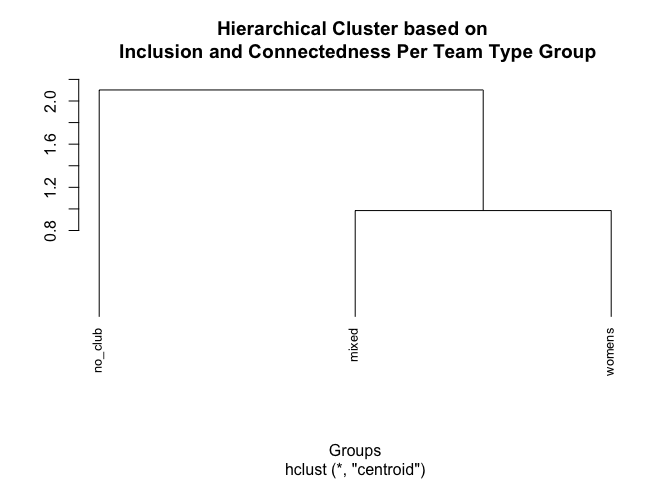

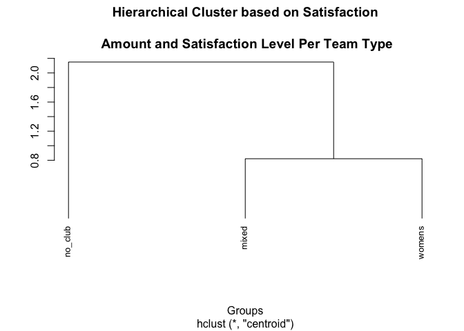

Drilling down into `team`, what’s driving the dissatisfaction among `no_club` players?

- People who don’t play any club at all (p = 0.00112)

```
##
## Call:
## lm(formula = overall ~ team, data = all)
##
## Residuals:
##     Min      1Q  Median      3Q     Max
## -14.269  -3.733   0.050   3.483  14.731
##
## Coefficients:
##                    Estimate Std. Error t value Pr(>|t|)
## (Intercept)         39.1875     1.3490  29.049  < 2e-16 ***
## teamELevate         -0.2875     2.1752  -0.132  0.89502
## teamFrenzy           1.4125     1.9393   0.728  0.46751
## teamNo-Club         -4.9183     1.4809  -3.321  0.00112 **
## teamNon-Chicago     -1.4875     2.1752  -0.684  0.49511
## teamJabba The Huck   3.8125     3.0165   1.264  0.20819
## teamNemesis          1.7014     2.2484   0.757  0.45038
## teamOther           -4.3542     2.5832  -1.686  0.09391 .
## teamShakedown        0.6458     2.5832   0.250  0.80291
## teamStack Cats       0.8125     2.4453   0.332  0.74014
## teamUPA             -0.1875     3.3949  -0.055  0.95603
## ---
## Signif. codes:  0 '***' 0.001 '**' 0.01 '*' 0.05 '.' 0.1 ' ' 1
##
## Residual standard error: 5.396 on 153 degrees of freedom
## Multiple R-squared:  0.2292, Adjusted R-squared:  0.1788
## F-statistic: 4.549 on 10 and 153 DF,  p-value: 1.204e-05
```

- All other models with a single predictor variable predicting `overall` were not significant.

#### Satisfaction Measures

What about the effect of team type on satisfaction of just the **level** of ultimate you’re playing?

- Make two models, one with `team_type` as a predictor and one without
- Compare the performance of the models in predicting satisfaction level
- The model with team type does’t predict satisfaction level better than the one without it (p = 0.6361).
- So team_type is not a significant predictor of satisfaciton with the level of ultimate you’re playing.

```
## Likelihood ratio tests of cumulative link models:
##
##                         formula:                             link:
## m.satis_level_no.team_t satis_level_recode ~ age             probit
## m.satis_level_team_t    satis_level_recode ~ team_type + age probit
##                         threshold:
## m.satis_level_no.team_t flexible
## m.satis_level_team_t    flexible
##
##                         no.par    AIC  logLik LR.stat df Pr(>Chisq)
## m.satis_level_no.team_t      9 401.10 -191.55
## m.satis_level_team_t        11 404.19 -191.10  0.9048  2     0.6361
```

What about satisfaction with the **amount** of ultimate you’re playing?

- Same procedure

Model with team type *does* predict satisfaction level better than the one without it (p = 0.0072)

```
## Likelihood ratio tests of cumulative link models:
##
##                         formula:                              link:
## m.sais_amount_no.team_t satis_amount_recode ~ age             probit
## m.sais_amount_team_t    satis_amount_recode ~ team_type + age probit
##                         threshold:
## m.sais_amount_no.team_t flexible
## m.sais_amount_team_t    flexible
##
##                         no.par    AIC  logLik LR.stat df Pr(>Chisq)
## m.sais_amount_no.team_t     10 480.57 -230.29
## m.sais_amount_team_t        12 474.71 -225.35  9.8677  2   0.007199 **
## ---
## Signif. codes:  0 '***' 0.001 '**' 0.01 '*' 0.05 '.' 0.1 ' ' 1
```

* And that difference is borne out in this graph (check that leftmost bar)

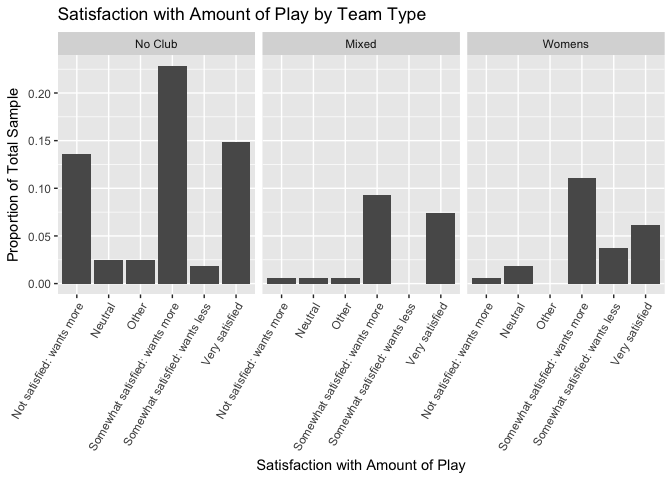

Okay so there’s a there there with `team_type`. So does `team_type` pedict overall satisfaction, inclusion, connection, and all of the above?

**Do womens and mixed players have significantly higher overall satisfaction, connectedness, and inclusion than non-club players?**

Satisfaction: yes (p = 0.0252)

```
##
## Call:
## lm(formula = satis_combined ~ team_type, data = all)
##
## Residuals:
##     Min      1Q  Median      3Q     Max
## -8.4333 -1.4333  0.5667  1.8830  3.8830
##
## Coefficients:
##                 Estimate Std. Error t value Pr(>|t|)
## (Intercept)      10.1170     0.2679  37.766   <2e-16 ***
## team_typemixed    1.3163     0.5446   2.417   0.0168 *
## team_typewomens   1.1080     0.4903   2.260   0.0252 *
## ---
## Signif. codes:  0 '***' 0.001 '**' 0.01 '*' 0.05 '.' 0.1 ' ' 1
##
## Residual standard error: 2.597 on 161 degrees of freedom
## Multiple R-squared:  0.05091,    Adjusted R-squared:  0.03912
## F-statistic: 4.318 on 2 and 161 DF,  p-value: 0.0149
```

Connection: yes (p = 1.17e-07)

```
##
## Call:
## lm(formula = conn_combined ~ team_type, data = all)
##
## Residuals:
##     Min      1Q  Median      3Q     Max
## -7.1750 -2.1898 -0.2045  1.8250  7.7660
##
## Coefficients:
##                 Estimate Std. Error t value Pr(>|t|)
## (Intercept)       9.2340     0.2897  31.875  < 2e-16 ***
## team_typemixed    1.8993     0.5890   3.225  0.00153 **
## team_typewomens   2.9410     0.5302   5.547 1.17e-07 ***
## ---
## Signif. codes:  0 '***' 0.001 '**' 0.01 '*' 0.05 '.' 0.1 ' ' 1
##
## Residual standard error: 2.809 on 161 degrees of freedom
## Multiple R-squared:  0.1744, Adjusted R-squared:  0.1641
## F-statistic:    17 on 2 and 161 DF,  p-value: 1.998e-07
```

Inclusion: yes (p = 0.00245)

```
##
## Call:
## lm(formula = inclus_combined ~ team_type, data = all)
##
## Residuals:
##     Min      1Q  Median      3Q     Max
## -6.7000 -1.4250 -0.3191  1.6809  4.6809
##
## Coefficients:
##                 Estimate Std. Error t value Pr(>|t|)
## (Intercept)      15.3191     0.2451  62.490  < 2e-16 ***
## team_typemixed    2.0142     0.4984   4.041 8.21e-05 ***
## team_typewomens   1.3809     0.4487   3.078  0.00245 **
## ---
## Signif. codes:  0 '***' 0.001 '**' 0.01 '*' 0.05 '.' 0.1 ' ' 1
##
## Residual standard error: 2.377 on 161 degrees of freedom
## Multiple R-squared:  0.1135, Adjusted R-squared:  0.1025
## F-statistic:  10.3 on 2 and 161 DF,  p-value: 6.156e-05
```

Overall: yes (p = 2.82e-07)

```
##
## Call:
## lm(formula = overall ~ team_type, data = all)
##
## Residuals:
##     Min      1Q  Median      3Q     Max
## -14.670  -3.670   0.100   3.472  15.330
##
## Coefficients:
##                 Estimate Std. Error t value Pr(>|t|)
## (Intercept)      34.6702     0.5533  62.661  < 2e-16 ***
## team_typemixed    5.2298     1.1249   4.649 6.90e-06 ***
## team_typewomens   5.4298     1.0127   5.362 2.82e-07 ***
## ---
## Signif. codes:  0 '***' 0.001 '**' 0.01 '*' 0.05 '.' 0.1 ' ' 1
##
## Residual standard error: 5.364 on 161 degrees of freedom
## Multiple R-squared:  0.1984, Adjusted R-squared:  0.1884
## F-statistic: 19.92 on 2 and 161 DF,  p-value: 1.861e-08
```

Is there a significant difference in combined satisfaction and inclusion scores between womens and mixed players? No, p = 0.841

```
##
## Call:
## lm(formula = overall ~ team_type, data = all[all$team_type %in%
##     c("womens", "mixed"), ])
##
## Residuals:
##    Min     1Q Median     3Q    Max
## -12.10  -2.05   0.10   2.90   9.10
##
## Coefficients:
##                 Estimate Std. Error t value Pr(>|t|)
## (Intercept)      39.9000     0.7516  53.089   <2e-16 ***
## team_typewomens   0.2000     0.9942   0.201    0.841
## ---
## Signif. codes:  0 '***' 0.001 '**' 0.01 '*' 0.05 '.' 0.1 ' ' 1
##
## Residual standard error: 4.117 on 68 degrees of freedom
## Multiple R-squared:  0.0005947,  Adjusted R-squared:  -0.0141
## F-statistic: 0.04047 on 1 and 68 DF,  p-value: 0.8412
```

So, narrowing down to club or not, is playing club at all a significant predictor of overall happiness with ultimate in Chicago?

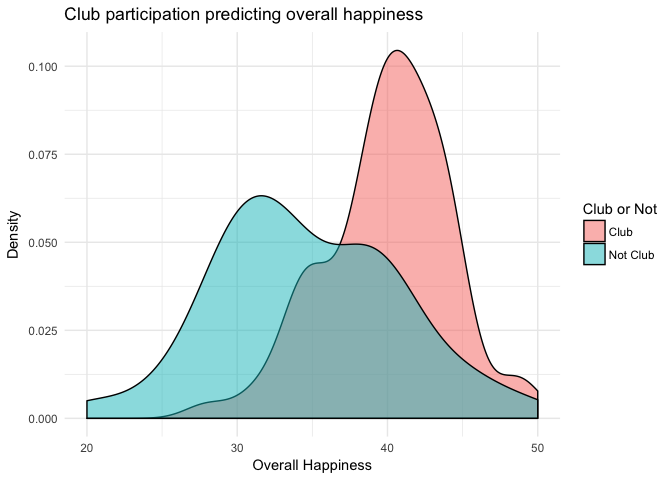

Yes, p = 2.32e-09

```
##
## Call:
## lm(formula = overall ~ club_or_not, data = all)
##
## Residuals:
##      Min       1Q   Median       3Q      Max
## -14.6702  -3.6702  -0.0143   3.4938  15.3298
##
## Coefficients:
##                     Estimate Std. Error t value Pr(>|t|)
## (Intercept)          40.0143     0.6392  62.597  < 2e-16 ***
## club_or_notnot_club  -5.3441     0.8443  -6.329 2.32e-09 ***
## ---
## Signif. codes:  0 '***' 0.001 '**' 0.01 '*' 0.05 '.' 0.1 ' ' 1
##
## Residual standard error: 5.348 on 162 degrees of freedom
## Multiple R-squared:  0.1983, Adjusted R-squared:  0.1933
## F-statistic: 40.06 on 1 and 162 DF,  p-value: 2.315e-09
```

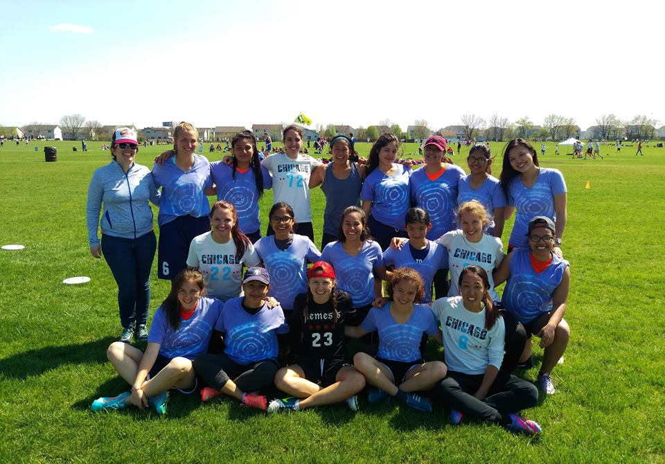

#### Future directions

- Merge with Ultimate Chicago stats of where people are playing based on league, college, and club data
- Merge with qualitative data
- NLP on free responses
- Remove players who play club outside of Chicago from the `no_club` group